# R Notebook

This vignette is in addition to the main vignette for the package but shows an analysis using geodesic distances (as the fish swims rather than as the crow flies).

```r
require(MRSea)
```

1. Load the distance sampling corrected Nysted data from the package.

```r
data("Nysted.distancecorrected.re")
```

2. Fit an initial Model to the data. Here we include only the `impact` variable as a factor along with the offset of cell area.

```r
mydata$blockid <- paste(mydata$transect.id, mydata$season, mydata$impact,sep = "")
mydata$foldid <- getCVids(data = mydata, folds = 5, block = 'blockid')
salsa1dlist <- list(fitnessMeasure = "QBIC", minKnots_1d = 2,maxKnots_1d = 5,
                    startKnots_1d = 1, degree = 2, maxIterations = 10,
                    gaps = c(0))
```

```r
initialModel <- glm(response ~ as.factor(impact)
                    + offset(log(area)), family = "quasipoisson",
                    data = mydata)
```

```r
# run SALSA
salsa1dOutput <- runSALSA1D(initialModel, salsa1dlist, c("depth"),
                      predictionData=predictData, datain=data, removal=TRUE, panelid = data$blockid)
```

Use the built in summary function (`summary.gamMRSea`) to look at the summary of the model. Note that robust standard errors are given alongside the raw standard erorrs and information regarding panels is at the bottom of the output. If each data point is a panel, then independence is assumed.

```r
summary(salsa1dOutput$bestModel)
```

```
Call:
glm(formula = response ~ as.factor(impact) + bs(depth, knots = splineParams[[2]]$knots,
    degree = splineParams[[2]]$degree, Boundary.knots = splineParams[[2]]$bd) +
    offset(log(area)), family = quasipoisson(link = log), data = mydata)

Deviance Residuals:
    Min       1Q   Median       3Q      Max
-1.6465  -1.2814  -0.4961  -0.0798  20.0998

Coefficients:
                   Estimate Std. Error Robust S.E. t value Pr(>|t|)
(Intercept)        -1.56083    3.94588     1.01150  -1.543 0.122843
as.factor(impact)1 -0.07542    0.09159     0.15585  -0.484 0.628449
s(depth)1          -4.07922    7.57138     1.79770  -2.269 0.023283 *
s(depth)2          -3.70215    4.18602     1.69241  -2.187 0.028731 *
s(depth)3          -0.24581    4.01186     1.21218  -0.203 0.839309
s(depth)4           2.59441    3.94556     1.02470   2.532 0.011362 *
s(depth)5           3.51727    3.94943     0.98997   3.553 0.000383 ***
s(depth)6           2.23351    3.95117     1.06039   2.106 0.035204 *
s(depth)7           0.40989    3.97234     1.09717   0.374 0.708721
---
Signif. codes:  0 ‘***’ 0.001 ‘**’ 0.01 ‘*’ 0.05 ‘.’ 0.1 ‘ ’ 1

(Dispersion parameter for quasipoisson family taken to be 9.001041)

    Null deviance: 26054  on 9231  degrees of freedom
Residual deviance: 20632  on 9223  degrees of freedom
AIC:  NA

Max Panel Size = 54; Number of panels = 208
Number of Fisher Scoring iterations: 7
```

```r
# How many knots were chosen for depth?
salsa1dOutput$splineParams[[2]]$knots
```

```
[1] -23.9085 -19.2090 -14.5095  -9.8100  -5.1105
```

```r
# ~~~~~~~~~~~~~~~~~~~~~~~
```

3. Create a grid of knots that will be used as possible knot locations. Create one grid for before and one for after:

```r
knotgrid0<- getKnotgrid(coordData = cbind(mydata$x.pos[mydata$impact==0], mydata$y.pos[mydata$impact==0]), numKnots = 200, plot = FALSE)
knotgrid1<- getKnotgrid(coordData = cbind(mydata$x.pos[mydata$impact==1], mydata$y.pos[mydata$impact==1]), numKnots = 200, plot = FALSE)
```

```r
myknots<-rbind(knotgrid0,knotgrid1)
```

5. Create 3d distances between knots!

```r
datacoords<-mydata[,c('x.pos', 'y.pos', 'impact')]
d2k<- matrix(Inf, ncol=(nrow(knotgrid0) + nrow(knotgrid1)), nrow=length(datacoords[,1]))
d2k0 = d2k1 = matrix(0, ncol=dim((knotgrid0))[1], nrow=length(datacoords[datacoords$impact==0,1]))
for(i in 1:dim(knotgrid0)[1]){
    d2k0[,i]<- sqrt((datacoords[datacoords$impact==0,1]-knotgrid0[i,1])**2 + (datacoords[datacoords$impact==0,2]-knotgrid0[i,2])**2)
}
for(i in 1:dim(knotgrid1)[1]){
    d2k1[,i]<- sqrt((datacoords[datacoords$impact==1,1]-knotgrid1[i,1])**2 + (datacoords[datacoords$impact==1,2]-knotgrid1[i,2])**2)
}
d2k[1:nrow(d2k0), 1:ncol(d2k0)]<-d2k0
d2k[(nrow(d2k0)+1):nrow(d2k), (ncol(d2k0)+1):(ncol(d2k))]<-d2k1
```

knot to knot matrix:

```r
k2k<- matrix(Inf, ncol=(nrow(knotgrid0) + nrow(knotgrid1)), nrow=(nrow(knotgrid0) + nrow(knotgrid1)))
k2k0 = k2k1 = matrix(0, ncol=dim((knotgrid0))[1], nrow=dim(knotgrid0)[1])
for(i in 1:dim(knotgrid0)[1]){
    k2k0[,i]<- sqrt((knotgrid0[,1]-knotgrid0[i,1])**2 + (knotgrid0[,2]-knotgrid0[i,2])**2)
}
for(i in 1:dim(knotgrid1)[1]){
    k2k1[,i]<- sqrt((knotgrid1[,1]-knotgrid1[i,1])**2 + (knotgrid1[,2]-knotgrid1[i,2])**2)
}
k2k[1:nrow(k2k0), 1:ncol(k2k0)]<-k2k0
k2k[(nrow(k2k0)+1):nrow(k2k), (ncol(k2k0)+1):(ncol(k2k))]<-k2k1
```

```r
# make parameter set for running salsa2d
salsa2dlist<-list(fitnessMeasure = 'QBIC', knotgrid = myknots,
                 startKnots=5, minKnots=4, maxKnots=12, gap=0)
```

7. Run SALSA2D to find the appropriate number and location of knots for the 2D smooth term of `x.pos` and `y.pos`.

```r
salsa2dOutput<-runSALSA2D(salsa1dOutput$bestModel, salsa2dlist,
                             d2k=distMatsGeo$dataDist, k2k=distMatsGeo$knotDist)
```

```r
plot(mydata$x.pos, mydata$y.pos, col="grey", pch=16,
    xlab="X", ylab="Y", asp=1)
points(myknots, col=1)
```

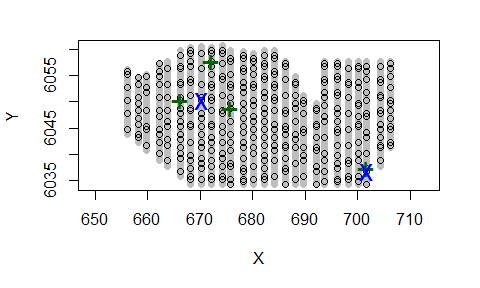

```r
points(myknots[salsa2dOutput$aR[[1]][salsa2dOutput$aR[[1]]<201],],
       col="darkgreen", cex=2, pch="+")
points(myknots[salsa2dOutput$aR[[1]][salsa2dOutput$aR[[1]]>201],],
       col="blue", pch="x", cex=2)
```

```r
salsa2dOutput$aR[[1]]
```

```
[1]  53 311 129  13 150 244
```

```r
data("nysted.predictdata")
datacoords<-nysted.predictdata[,c('x.pos', 'y.pos', 'impact')]
d2k<- matrix(Inf, ncol=(nrow(knotgrid0) + nrow(knotgrid1)), nrow=length(datacoords[,1]))
d2k0 = d2k1 = matrix(0, ncol=dim((knotgrid0))[1], nrow=length(datacoords[datacoords$impact==0,1]))
for(i in 1:dim(knotgrid0)[1]){
    d2k0[,i]<- sqrt((datacoords[datacoords$impact==0,1]-knotgrid0[i,1])**2 + (datacoords[datacoords$impact==0,2]-knotgrid0[i,2])**2)
}
for(i in 1:dim(knotgrid1)[1]){
    d2k1[,i]<- sqrt((datacoords[datacoords$impact==1,1]-knotgrid1[i,1])**2 + (datacoords[datacoords$impact==1,2]-knotgrid1[i,2])**2)
}
d2k[1:nrow(d2k0), 1:ncol(d2k0)]<-d2k0
d2k[(nrow(d2k0)+1):nrow(d2k), (ncol(d2k0)+1):(ncol(d2k))]<-d2k1
```

```r
#newmod<-update(salsa2dOutput$bestModel, .~. - LocalRadialFunction(radiusIndices, dists, radii, aR):as.factor(impact))
# make predictions on response scale
preds<-predict.gamMRSea(newdata = nysted.predictdata, g2k = d2k, object = salsa2dOutput$bestModel)
```

```r
cv.gamMRSea(mydata, salsa2dOutput$bestModel, K=10)$delta
```

```
[1] 5.941463 5.938282
```

Plotting the predictions pre and post impact:

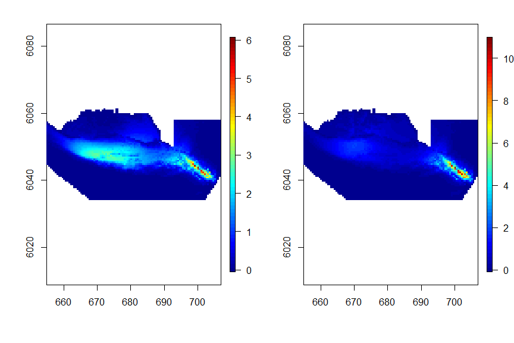

```r
par(mfrow=c(1,2))
quilt.plot(nysted.predictdata$x.pos[nysted.predictdata$impact==0],
           nysted.predictdata$y.pos[nysted.predictdata$impact==0],
           preds[nysted.predictdata$impact==0], nrow=104, ncol=55, asp=1)
quilt.plot(nysted.predictdata$x.pos[nysted.predictdata$impact==1],
           nysted.predictdata$y.pos[nysted.predictdata$impact==1],
           preds[nysted.predictdata$impact==1], nrow=104, ncol=55, asp=1)
```

```r
par(mfrow=c(1,2))
quilt.plot(nysted.predictdata$x.pos[nysted.predictdata$impact==0],
           nysted.predictdata$y.pos[nysted.predictdata$impact==0],
           nysted.predictdata$truth.re[nysted.predictdata$impact==0], nrow=104, ncol=55, asp=1)

quilt.plot(nysted.predictdata$x.pos[nysted.predictdata$impact==1],
           nysted.predictdata$y.pos[nysted.predictdata$impact==1],
           nysted.predictdata$truth.re[nysted.predictdata$impact==1], nrow=104, ncol=55, asp=1)
```

[output not shown]

```r
bootPreds<-do.bootstrap.cress.robust(salsa2dOutput$bestModel, predictionGrid = nysted.predictdata, splineParams=salsa2dOutput$bestModel$splineParams, g2k=d2k, B = 100, robust=TRUE)
```

```r
#load('predictionboot.RData')
cis <- makeBootCIs(bootPreds)
```

16. Calculate the differences before and after across all bootstraps

```r
differences <- getDifferences(beforePreds =
                      bootPreds[nysted.predictdata$impact == 0, ],
                      afterPreds = bootPreds[nysted.predictdata$impact == 1, ])
```

17. Plot differences and indicate where significant positive/negative differences lie.

```r
mediandiff <- differences$mediandiff
# The marker for each after - before difference:
# positive ('1') and negative ('-') significant differences
marker <- differences$significanceMarker
par(mfrow = c(1, 1))
quilt.plot(nysted.predictdata$x.pos[nysted.predictdata$impact == 0],
           nysted.predictdata$y.pos[nysted.predictdata$impact == 0],
           mediandiff, asp = 1, nrow = 104, ncol = 55)
# add + or - depending on significance of cells. Just
# requires one significance out of all to be allocated
points(nysted.predictdata$x.pos[nysted.predictdata$impact == 0][marker == 1],
       nysted.predictdata$y.pos[nysted.predictdata$impact == 0][marker == 1],
       pch = "+", col = "darkgrey", cex = 0.75)
```

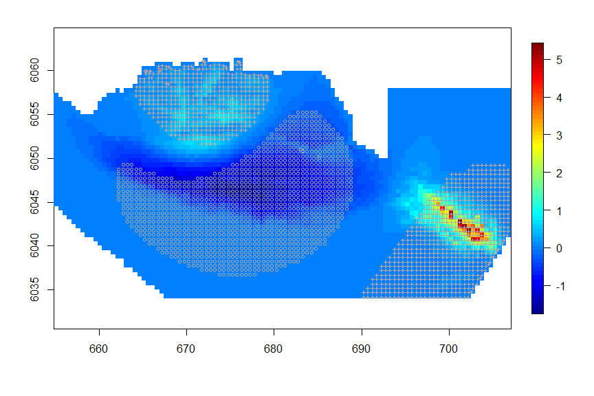

```r
points(nysted.predictdata$x.pos[nysted.predictdata$impact == 0][marker == (-1)],
       nysted.predictdata$y.pos[nysted.predictdata$impact == 0][marker == (-1)],
       col = "darkgrey", cex = 0.75)
points(681417.3, 6046910, cex = 3, pch = "*", lwd = 1, col = "grey")
```